# Exercise 6.5.4 - Decision Tree Modeling - Mortality Data

W. Mangrobang

September 03, 2018

### Problem Statement

**Repeat the process shown so far in this module to build a decision tree on the mortality data we used earlier in this course. Use actual_cnt = 0 and actual_cnt > 0 as the target variable.**

```r
library(caret)  #ML
library(rpart)  #Decision Trees
library(rpart.plot)  #Decision Tree plots
library(scales)  #formatting
library(kableExtra)  #formatting
library(tidyverse)  #tidy data
library(pROC)

# Set threshold
thresh_1 = 0.5
```

##### Prep Data

For the prescribed target variable I created a factor variable named ‘`is_claimant`’ for which:  
- `actual_cnt` == 0 -> ‘0’  
- `actual_cnt` > 0 -> ‘1’

For variables to include in the modeling, I removed any that were collinear with the target in a non-meaningful way; e.g. it’s not useful to know that `actual_cnt` will be split on, since we used it to define our target.

```r
# Import csv mort_raw <- read.csv(
# 'D:/Dropbox/PACP/data/soa_mortality_data.csv' )
mort_raw <- read.csv("/users/werlindo/Dropbox/PACP/data/soa_mortality_data.csv")
head(mort_raw, 6)
```

```
##   X policy.number prodcat issstate    region distchan smoker sex issage
## 1 1       1247363      WL       TN     South        A      S   M     34
## 2 2      24011357    ULSG       GA     South        A      N   F     55
## 3 3      10700572      WL       CT Northeast        A      N   F     58
## 4 4       5361544      UL       NC     South        I      N   M     70
## 5 5      19634287    ULSG       NJ Northeast        I      S   M     65
## 6 6      12025233      WL       WA      West        A      U   F     21
##   duration attage uwkey exposure_cnt exposure_face actual_cnt actual_face
## 1       33     66  bbb0       0.4027       2094.56          0           0
## 2        3     57  bbb0       0.7978     219399.40          0           0
## 3        2     59  1220       0.1233       2388.54          0           0
## 4        8     77  bbb0       0.3507      16131.28          0           0
## 5        6     70  bbb0       0.9151     411780.60          0           0
## 6       45     65  bbb0       0.6329       6582.16          0           0
##   expected_cnt expected_face uwtype resind_ind year test
## 1      0.00438       22.7864     NM          A 2009    3
## 2      0.00147      403.7000     NO          N 2008    1
## 3      0.00017        3.3182     MP          N 2010    1
## 4      0.00789      362.9584     GI          N 2009    1
## 5      0.01856     8350.9110     NO          N 2007    2
## 6      0.00716       74.4432     NM          N 2007    3
```

```r
# create binarized target
mort_raw$is_claimant[mort_raw$actual_cnt == 0] = 0
mort_raw$is_claimant[mort_raw$actual_cnt > 0] = 1
# table(mort_raw$is_claimant)
mort_raw$is_claimant <- as.factor(mort_raw$is_claimant)  # This is to force the logistic regression to predict 0/1

# Quick peek
str(mort_raw)
```

```
## 'data.frame':    500000 obs. of  23 variables:
##  $ X            : int  1 2 3 4 5 6 7 8 9 10 ...
##  $ policy.number: int  1247363 24011357 10700572 5361544 19634287 12025233 1613938 12020784 13884142 23782259 ...
##  $ prodcat      : Factor w/ 4 levels "TRM","UL","ULSG",..: 4 3 4 2 3 4 2 4 4 2 ...
##  $ issstate     : Factor w/ 53 levels "","AK","AL","AR",..: 44 12 8 29 33 50 21 49 37 26 ...
##  $ region       : Factor w/ 5 levels "Midwest","Northeast",..: 3 3 2 3 2 5 2 2 1 1 ...
##  $ distchan     : Factor w/ 4 levels "A","B","D","I": 1 1 1 4 4 1 1 1 4 1 ...
##  $ smoker       : Factor w/ 3 levels "N","S","U": 2 1 1 1 2 3 1 2 1 1 ...
##  $ sex          : Factor w/ 3 levels "F","M","U": 2 1 1 2 2 1 2 1 1 2 ...
##  $ issage       : int  34 55 58 70 65 21 39 35 71 34 ...
##  $ duration     : int  33 3 2 8 6 45 18 20 12 23 ...
##  $ attage       : int  66 57 59 77 70 65 56 54 82 56 ...
##  $ uwkey        : Factor w/ 14 levels "0bb0","0bb1",..: 13 13 5 13 13 13 1 13 7 13 ...
##  $ exposure_cnt : num  0.403 0.798 0.123 0.351 0.915 ...
##  $ exposure_face: num  2095 219399 2389 16131 411781 ...
##  $ actual_cnt   : int  0 0 0 0 0 0 0 0 0 0 ...
##  $ actual_face  : num  0 0 0 0 0 0 0 0 0 0 ...
##  $ expected_cnt : num  0.00438 0.00147 0.00017 0.00789 0.01856 ...
##  $ expected_face: num  22.79 403.7 3.32 362.96 8350.91 ...
##  $ uwtype       : Factor w/ 7 levels "GI","MP","NM",..: 3 4 2 1 4 3 2 3 2 3 ...
##  $ resind_ind   : Factor w/ 4 levels "A","F","N","R": 1 3 3 3 3 3 3 3 4 3 ...
##  $ year         : int  2009 2008 2010 2009 2007 2007 2007 2006 2009 2009 ...
##  $ test         : int  3 1 1 1 2 3 1 1 1 1 ...
##  $ is_claimant  : Factor w/ 2 levels "0","1": 1 1 1 1 1 1 1 1 1 1 ...
```

```r
# select variables available for training Take off actual_cnt and
# actual_face because, then you are using the target to predict :)
mort <- mort_raw[, setdiff(colnames(mort_raw), c("test", "X", "policy.number",
    "actual_cnt", "actual_face", "year"))]

# split data into training vs testing
set.seed(2425)
train_pct <- 0.8

train <- createDataPartition(mort_raw$is_claimant, p = train_pct, list = FALSE)

# allocate datasets
mort_train <- mort[train, ]
dim(mort_train)
```

```
## [1] 400000     17
```

```r
mort_test <- mort[-train, ]
dim(mort_test)
```

```
## [1] 100000     17
```

```r
# Set the formula with all variables
mort_dt_f <- as.formula(paste("is_claimant~", paste(names(mort_train[, -(which(names(mort_train) ==
    "is_claimant"))]), collapse = " + ")))
```

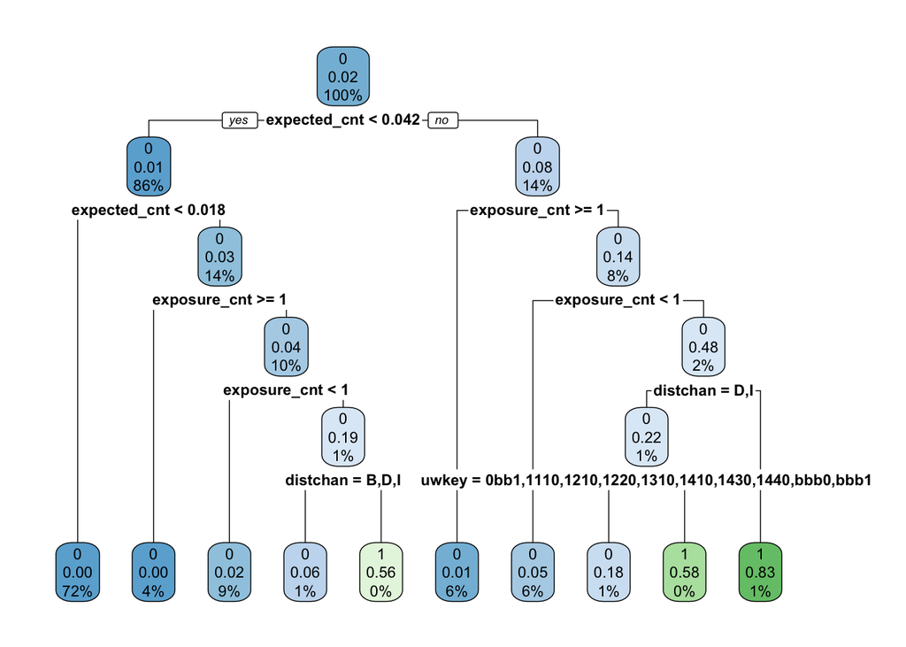

```r
# Fit a decision tree, method = 'class' ensures the target is treated as a
# categorical variable
mort_dt <- rpart(mort_dt_f, data = mort_train, method = "class", control = rpart.control(minbucket = 5,
    cp = 1e-05, maxdepth = 5), parms = list(split = "gini"))

# Plot the tree
rpart.plot(mort_dt)
```

```r
# look at the print summary
print(mort_dt)
```

```
## n= 400000
##
## node), split, n, loss, yval, (yprob)
##       * denotes terminal node
##
##  1) root 400000 7316 0 (0.9817100000 0.0182900000)
##    2) expected_cnt< 0.041955 343571 2859 0 (0.9916785759 0.0083214241)
##      4) expected_cnt< 0.018075 288705 1406 0 (0.9951299770 0.0048700230) *
##      5) expected_cnt>=0.018075 54866 1453 0 (0.9735172967 0.0264827033)
##       10) exposure_cnt>=1.00135 15797   11 0 (0.9993036653 0.0006963347) *
##       11) exposure_cnt< 1.00135 39069 1442 0 (0.9630909417 0.0369090583)
##         22) exposure_cnt< 0.99865 34920  654 0 (0.9812714777 0.0187285223) *
##         23) exposure_cnt>=0.99865 4149  788 0 (0.8100747168 0.1899252832)
##           46) distchan=B,D,I 3069  188 0 (0.9387422613 0.0612577387) *
##           47) distchan=A 1080  480 1 (0.4444444444 0.5555555556) *
##    3) expected_cnt>=0.041955 56429 4457 0 (0.9210157898 0.0789842102)
##      6) exposure_cnt>=1.00135 25289  230 0 (0.9909051366 0.0090948634) *
##      7) exposure_cnt< 1.00135 31140 4227 0 (0.8642581888 0.1357418112)
##       14) exposure_cnt< 0.99865 24768 1157 0 (0.9532864987 0.0467135013) *
##       15) exposure_cnt>=0.99865 6372 3070 0 (0.5182046453 0.4817953547)
##         30) distchan=D,I 3637  788 0 (0.7833379159 0.2166620841)
##           60) uwkey=0bb1,1110,1210,1220,1310,1410,1430,1440,bbb0,bbb1 3306  596 0 (0.8197217181 0.1802782819) *
##           61) uwkey=0bb0,1320,1330,1420 331  139 1 (0.4199395770 0.5800604230) *
##         31) distchan=A,B 2735  453 1 (0.1656307130 0.8343692870) *
```

```r
# look at the complexity parameter
printcp(mort_dt)
```

```
##
## Classification tree:
## rpart(formula = mort_dt_f, data = mort_train, method = "class",
##     parms = list(split = "gini"), control = rpart.control(minbucket = 5,
##         cp = 1e-05, maxdepth = 5))
##
## Variables actually used in tree construction:
## [1] distchan     expected_cnt exposure_cnt uwkey
##
## Root node error: 7316/400000 = 0.01829
##
## n= 400000
##
##          CP nsplit rel error  xerror     xstd
## 1 0.0625000      0   1.00000 1.00000 0.011584
## 2 0.0072444      4   0.75000 0.75041 0.010058
## 3 0.0041006      5   0.74276 0.74699 0.010035
## 4 0.0000100      9   0.72635 0.73237 0.009938
```

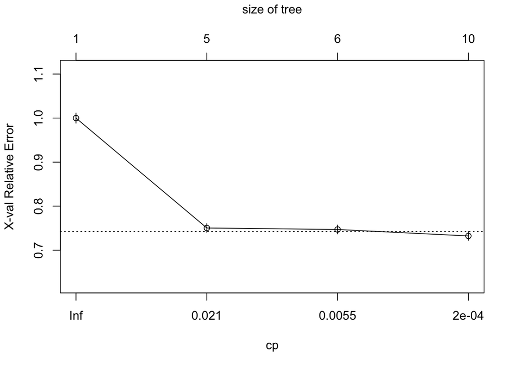

```r
plotcp(mort_dt)
```

```r
# Extract the optimal complexity of the tree by taking the one with the
# minimum xerror
mort_dt$cptable[which.min(mort_dt$cptable[, "xerror"]), "CP"]
```

```
## [1] 1e-05
```

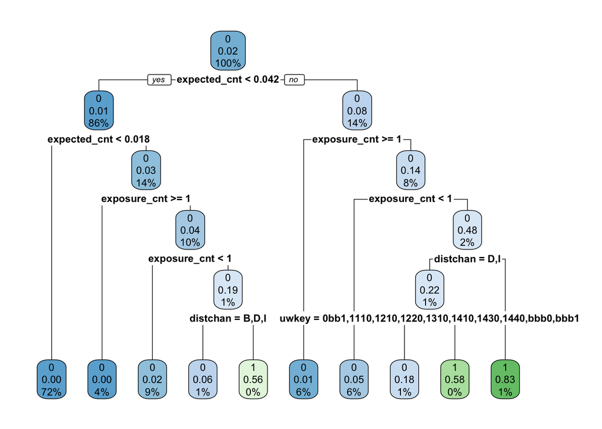

```r
# prune the tree
mort_dt_pruned_1 <- prune(mort_dt, cp = mort_dt$cptable[which.min(mort_dt$cptable[,
    "xerror"]), "CP"])

# Plot the tree
rpart.plot(mort_dt_pruned_1)
```

Went through one pruning based on minimum CV error, but the post-pruning tree is identical to the first one (We saw the same situation in the example in the lecture materials).

For fun lets look at some validation metrics.

##### Run predictions:

```r
# Predictions
# ---------------------------------------------------------------------
# Predict the probabilities
mort_dt_res_probs <- predict(mort_dt_pruned_1, newdata = mort_train, type = "prob")

# Create dataframe of predictions
mort_dt_res_preds <- data.frame(thresh_1 = as.factor(1 * (mort_dt_res_probs[,
    2] > thresh_1)))
```

##### Build confusion matrix:

```r
# Confusion Matrices
# ---------------------------------------------------------------------

# Create confusion matrices for the predictions
mort_dt_cm_1 <- confusionMatrix(mort_dt_res_preds$thresh_1, mort_train$is_claimant)

# Create dataframe of confusion matrices
mort_res_cm_df <- data.frame(as.data.frame.matrix(mort_dt_cm_1$table))

# Some column naming to support final output
mort_res_cm_df <- rownames_to_column(mort_res_cm_df, var = "Prediction")
colnames(mort_res_cm_df)[2:3] <- c("0", "1")

kable(mort_res_cm_df, caption = "Confusion Matrix | Mortality Data | Training Dataset | Decision Tree | Threshold = 50%") %>%
    kable_styling(full_width = FALSE) %>% column_spec(2, border_left = T) %>%
    add_header_above(c(` ` = 1, Reference = 2))
```

Confusion Matrix | Mortality Data | Training Dataset | Decision Tree | Threshold = 50%

| Prediction | Reference 0 | Reference 1 |
| --- | --- | --- |
| 0 | 391612 | 4242 |
| 1 | 1072 | 3074 |

##### ROC/AUC:

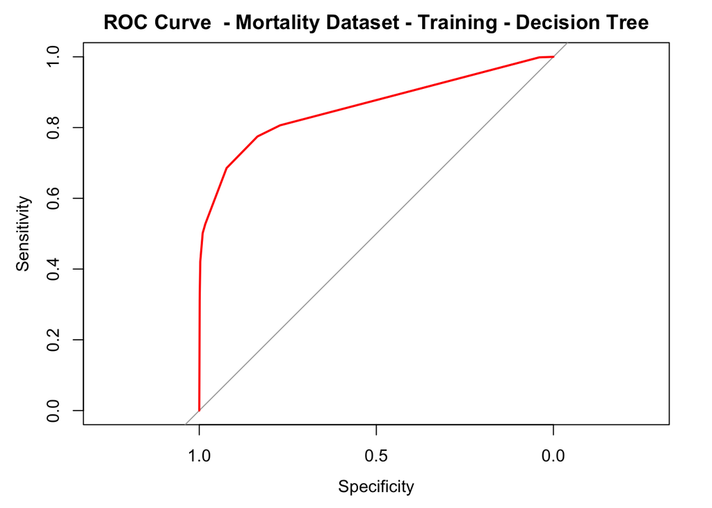

```r
# ROC Curve
# -------------------------------------------------------------------------
# Get ROC curve
plot(roc(as.numeric(mort_train$is_claimant), as.numeric(mort_dt_res_probs[,
    2])), col = "red", main = "ROC Curve  - Mortality Dataset - Training - Decision Tree")
```

```r
# AUC
# -------------------------------------------------------------------------------
# Get AUC for each model, put into matrix
a1 <- auc(mort_train$is_claimant, as.numeric(mort_dt_res_preds$thresh_1))
# a2 <- auc(mort_train$target, as.numeric(mort_dt_res_preds$thresh_2)) a3 <-
# auc(mort_train$target, as.numeric(mort_dt_res_preds$thresh_3))
aaa <- rbind(a1)

# Create df for eventual display
mort_dt_aucs <- data.frame(Threshold = c(thresh_1), AUC = aaa)
rownames(mort_dt_aucs) <- c()

# Make a kable
kable(mort_dt_aucs, caption = "AUC - Mortality Dataset Predictions | Training Dataset | Decision Tree") %>%
    kable_styling(full_width = FALSE)
```

AUC - Mortality Dataset Predictions | Training Dataset | Decision Tree

| Threshold | AUC |
| --- | --- |
| 0.5 | 0.7087225 |

But since this is an exercise in getting familiar with the methodology and code, let’s finish off by running the same diagnostics against test data.

##### Confusion Matrix for test data:

```r
# Confusion Matrices
# ---------------------------------------------------------------------
mort_dt_res_probs <- predict(mort_dt_pruned_1, newdata = mort_test, type = "prob")

# Create dataframe of predictions
mort_dt_res_preds <- data.frame(thresh_1 = as.factor(1 * (mort_dt_res_probs[,
    2] > thresh_1)))

# Create confusion matrices for the predictions
mort_dt_cm_2 <- confusionMatrix(mort_dt_res_preds$thresh_1, mort_test$is_claimant)

# Create dataframe of confusion matrices
mort_res_cm_df <- data.frame(as.data.frame.matrix(mort_dt_cm_2$table))

# Some column naming to support final output
mort_res_cm_df <- rownames_to_column(mort_res_cm_df, var = "Prediction")
colnames(mort_res_cm_df)[2:3] <- c("0", "1")

kable(mort_res_cm_df, caption = "Confusion Matrix | Mortality Data | Test Dataset | Decision Tree | Threshold = 50%") %>%
    kable_styling(full_width = FALSE) %>% column_spec(2, border_left = T) %>%
    add_header_above(c(` ` = 1, Reference = 2))
```

Confusion Matrix | Mortality Data | Test Dataset | Decision Tree | Threshold = 50%

| Prediction | Reference 0 | Reference 1 |
| --- | --- | --- |
| 0 | 97905 | 1058 |
| 1 | 266 | 771 |

##### ROC/AUC for test data:

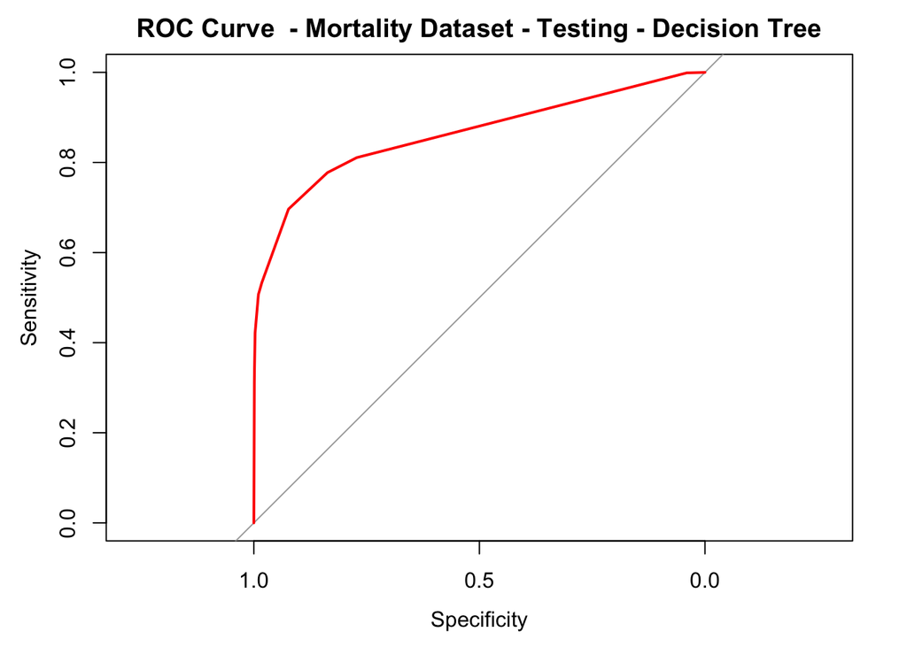

```r
# ROC Curve
# -------------------------------------------------------------------------
# Get ROC curve
plot(roc(as.numeric(mort_test$is_claimant), as.numeric(mort_dt_res_probs[, 2])),
    col = "red", main = "ROC Curve  - Mortality Dataset - Testing - Decision Tree")
```

```r
# AUC
# -------------------------------------------------------------------------------
# Get AUC for each model, put into matrix
a1 <- auc(mort_test$is_claimant, as.numeric(mort_dt_res_preds$thresh_1))
# a2 <- auc(mort_test$target, as.numeric(mort_dt_res_preds$thresh_2)) a3 <-
# auc(mort_test$target, as.numeric(mort_dt_res_preds$thresh_3))
aaa <- rbind(a1)

# Create df for eventual display
mort_dt_aucs <- data.frame(Threshold = c(thresh_1), AUC = aaa)
rownames(mort_dt_aucs) <- c()

# Make a kable
kable(mort_dt_aucs, caption = "AUC - Mortality Dataset Predictions | Test Dataset | Decision Tree") %>%
    kable_styling(full_width = FALSE)
```

AUC - Mortality Dataset Predictions | Test Dataset | Decision Tree

| Threshold | AUC |
| --- | --- |
| 0.5 | 0.7094161 |

Virtually same as train set. So for now, doesn’t feel like there is any overfitting happening.